# UnimedTest

Elaine Cristina Rocha

29 de outubro de 2017

## Análise de Clientes de Corretora

A Empresa X é uma corretora de valores que ajuda milhares de clientes a investir seu dinheiro de uma forma fácil e ágil. Seus produtos oferecem uma plataforma online e mobile de negociação de títulos públicos entre pessoas físicas e o programa do Tesouro Direto do governo.

Todo dia milhares de pessoas se tornam nosso clientes e a variabilidade de suas características é impressionante. São pessoas com características parecidas ou pessoas totalmente diferente.

```r
start.time <- Sys.time()

library(xlsx)
#Realizando a leitura do dataset
dataset <- read.xlsx("DataSet.xlsx",sheetIndex=1,header=TRUE, encoding="UTF-8")

#Se houverem dados NA, realizo a limpeza
dataset <- na.omit(dataset)

head(dataset)
```

```
##   ID GEO_REFERENCIA DATA_NASCIMENTO                  PROFISSAO GENERO
## 1  1            780      1992-08-15       ANALISTA DE SISTEMAS      M
## 2  2             35      1990-02-24  SERVIDOR PÚBLICO ESTADUAL      F
## 3  3             54      1987-07-17       ANALISTA DE SISTEMAS      M
## 4  4             35      1988-04-27     BANCARIO E ECONOMIÁRIO      M
## 5  5            883      1971-12-10 SERVIDOR PÚBLICO MUNICIPAL      M
## 6  6             78      1986-06-22                   AUTÔNOMO      M
##                          ESTADO_CIVIL  VALOR_01 VALOR_02 VALOR_03
## 1                         SOLTEIRO(A)  342.8571 342.8571 428.5714
## 2                         SOLTEIRO(A)  942.8571   0.0000   0.0000
## 3                         SOLTEIRO(A) 2000.0000   0.0000   0.0000
## 4 CASADO(A) COM BRASILEIRO(A) NATO(A)  857.1429 285.7143   0.0000
## 5 CASADO(A) COM BRASILEIRO(A) NATO(A) 8615.3857   0.0000   0.0000
## 6                         SOLTEIRO(A)  571.4286 410.3086   0.0000
##      VALOR_04 PERFIL
## 1    28.57143      A
## 2     0.00000      A
## 3  2857.14286      A
## 4  1428.57143      A
## 5 47471.78857      A
## 6    57.14286      B
```

## Calculando idade e totalizando valores

Como temos a coluna DATA_NASCIMENTO, vamos facilitar a avaliação dos dados convertendo a data para uma nova coluna IDADE. Estou entendendo que as colunas VALOR_01, VALOR_02, VALOR_03 e VALOR_04 representam investimentos de cada cliente, por isso para facilitar estou totalizando esses valores em VLR_TOTAL.

```r
#Iniciando um cálculo de idade dos clientes
dataAtual <- format(Sys.time(), "%Y-%m-%d")
dataset$IDADE <- as.integer((as.Date(dataAtual) - as.Date(format(as.Date(dataset$DATA_NASCIMENTO), "%Y-%m-%d")))/365)

#Criando uma coluna com total dos Valores de 01 a 04
dataset$VLR_TOTAL <- (dataset$VALOR_01 + dataset$VALOR_02 + dataset$VALOR_03 + dataset$VALOR_04)

head(dataset)
```

```
##   ID GEO_REFERENCIA DATA_NASCIMENTO                  PROFISSAO GENERO
## 1  1            780      1992-08-15       ANALISTA DE SISTEMAS      M
## 2  2             35      1990-02-24  SERVIDOR PÚBLICO ESTADUAL      F
## 3  3             54      1987-07-17       ANALISTA DE SISTEMAS      M
## 4  4             35      1988-04-27     BANCARIO E ECONOMIÁRIO      M
## 5  5            883      1971-12-10 SERVIDOR PÚBLICO MUNICIPAL      M
## 6  6             78      1986-06-22                   AUTÔNOMO      M
##                          ESTADO_CIVIL  VALOR_01 VALOR_02 VALOR_03
## 1                         SOLTEIRO(A)  342.8571 342.8571 428.5714
## 2                         SOLTEIRO(A)  942.8571   0.0000   0.0000
## 3                         SOLTEIRO(A) 2000.0000   0.0000   0.0000
## 4 CASADO(A) COM BRASILEIRO(A) NATO(A)  857.1429 285.7143   0.0000
## 5 CASADO(A) COM BRASILEIRO(A) NATO(A) 8615.3857   0.0000   0.0000
## 6                         SOLTEIRO(A)  571.4286 410.3086   0.0000
##      VALOR_04 PERFIL IDADE  VLR_TOTAL
## 1    28.57143      A    25  1142.8571
## 2     0.00000      A    27   942.8571
## 3  2857.14286      A    30  4857.1429
## 4  1428.57143      A    29  2571.4286
## 5 47471.78857      A    45 56087.1743
## 6    57.14286      B    31  1038.8800
```

## Sumarizando os dados e plotando um boxplot para ter uma noção melhor do ambiente

```r
summary(dataset)
```

```
##        ID       GEO_REFERENCIA  DATA_NASCIMENTO
##  Min.   :   1   Min.   : 10.0   Min.   :1925-11-03 00:00:00
##  1st Qu.:1244   1st Qu.: 70.0   1st Qu.:1977-07-15 18:00:00
##  Median :2486   Median :224.0   Median :1984-04-05 00:00:00
##  Mean   :2486   Mean   :336.8   Mean   :1981-12-07 07:32:43
##  3rd Qu.:3729   3rd Qu.:607.0   3rd Qu.:1989-02-14 06:00:00
##  Max.   :4972   Max.   :999.0   Max.   :2016-08-01 00:00:00
##
##                     PROFISSAO    GENERO
##  ANALISTA DE SISTEMAS    : 564   F:1107
##  ENGENHEIRO              : 505   M:3865
##  ADMINISTRADOR           : 442
##  ESTUDANTE               : 409
##  SERVIDOR PÚBLICO FEDERAL: 279
##  AUTÔNOMO                : 269
##  (Other)                 :2504
##                               ESTADO_CIVIL     VALOR_01
##  SOLTEIRO(A)                        :2584   Min.   :     0.0
##  CASADO(A) COM BRASILEIRO(A) NATO(A):1870   1st Qu.:   628.6
##  UNIAO ESTAVEL                      : 267   Median :  1371.4
##  DIVORCIADO(A)                      : 164   Mean   :  2022.7
##  VIUVO(A)                           :  35   3rd Qu.:  2571.4
##  CASADO(A) COM ESTRANGEIRO(A)       :  20   Max.   :400000.0
##  (Other)                            :  32
##     VALOR_02          VALOR_03          VALOR_04      PERFIL
##  Min.   :      0   Min.   :      0   Min.   :     0   A:3489
##  1st Qu.:      0   1st Qu.:      0   1st Qu.:     0   B:1105
##  Median :      0   Median :      0   Median :     0   C: 245
##  Mean   :  18638   Mean   :   4246   Mean   :  5041   D: 133
##  3rd Qu.:   6006   3rd Qu.:      0   3rd Qu.:  1429
##  Max.   :2857143   Max.   :1428571   Max.   :685714
##
##      IDADE         VLR_TOTAL
##  Min.   : 1.00   Min.   :      0.0
##  1st Qu.:28.00   1st Qu.:    914.3
##  Median :33.00   Median :   2714.3
##  Mean   :35.42   Mean   :  29948.1
##  3rd Qu.:40.00   3rd Qu.:  18083.4
##  Max.   :92.00   Max.   :2874285.7
##
```

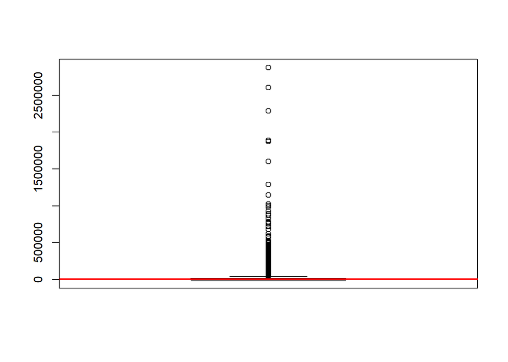

```r
quartil1 <- 914.3  #dado proveniente do summary
media <- 29948.1 #dado proveniente do summary
mediana <- 2714.3 #dado proveniente do summary
quartil3 <- 18083.4 #dado proveniente do summary

boxplot(dataset$VLR_TOTAL, col='blue')
abline(h=mediana, col="green")
abline(h=quartil1, col="red")
abline(h=quartil3, col="red")
```

Observando o boxplot gerado podemos perceber que possuímos outliers, então é interessante fazer um corte no meu dataset para eliminar parte dos outliers.

## Avaliando se temos uma distribuição normal nas colunas de valores

```r
shapiro.test(dataset$VALOR_01 + dataset$VALOR_02 + dataset$VALOR_03 + dataset$VALOR_04 + dataset$VLR_TOTAL)
```

```
##
##  Shapiro-Wilk normality test
##
## data:  dataset$VALOR_01 + dataset$VALOR_02 + dataset$VALOR_03 + dataset$VALOR_04 +     dataset$VLR_TOTAL
## W = 0.23805, p-value < 2.2e-16
```

Como temos um p-value menor que 0.05 então sabemos que não temos uma distribuição normal.

## Teste de hipótese

Sabendo que não temos uma distribuição normal, vamos avaliar se a idade possui relação com o valor total através do teste de Wilcoxon.

```r
wilcox.test(dataset$IDADE, dataset$VLR_TOTAL)
```

```
##
##  Wilcoxon rank sum test with continuity correction
##
## data:  dataset$IDADE and dataset$VLR_TOTAL
## W = 39476, p-value < 2.2e-16
## alternative hypothesis: true location shift is not equal to 0
```

Obtendo um p-value muito próximo de zero podemos anular a hipótese de que a idade possui realação com o total do valor investido.

## Vendo se existe alguma relação entre idade e valores total através de regressão linear

```r
linearModel <- lm(IDADE ~ VALOR_01 + VALOR_02 + VALOR_03 + VALOR_04 + VLR_TOTAL, dataset)
linearModel
```

```
##
## Call:
## lm(formula = IDADE ~ VALOR_01 + VALOR_02 + VALOR_03 + VALOR_04 +
##     VLR_TOTAL, data = dataset)
##
## Coefficients:
## (Intercept)     VALOR_01     VALOR_02     VALOR_03     VALOR_04
##   3.446e+01    1.534e-04    1.881e-05    2.379e-05    4.063e-05
##   VLR_TOTAL
##          NA
```

```r
summary(linearModel)
```

```
##
## Call:
## lm(formula = IDADE ~ VALOR_01 + VALOR_02 + VALOR_03 + VALOR_04 +
##     VLR_TOTAL, data = dataset)
##
## Residuals:
##     Min      1Q  Median      3Q     Max
## -63.826  -6.707  -2.199   4.258  56.029
##
## Coefficients: (1 not defined because of singularities)
##              Estimate Std. Error t value Pr(>|t|)
## (Intercept) 3.446e+01  1.604e-01 214.815  < 2e-16 ***
## VALOR_01    1.534e-04  2.458e-05   6.242 4.69e-10 ***
## VALOR_02    1.881e-05  1.751e-06  10.741  < 2e-16 ***
## VALOR_03    2.379e-05  4.036e-06   5.895 4.00e-09 ***
## VALOR_04    4.063e-05  6.549e-06   6.203 5.99e-10 ***
## VLR_TOTAL          NA         NA      NA       NA
## ---
## Signif. codes:  0 '***' 0.001 '**' 0.01 '*' 0.05 '.' 0.1 ' ' 1
##
## Residual standard error: 10.47 on 4967 degrees of freedom
## Multiple R-squared:  0.06353,    Adjusted R-squared:  0.06278
## F-statistic: 84.24 on 4 and 4967 DF,  p-value: < 2.2e-16
```

Através da sumarização do modelo linear acima vemos que os seus p-values são baixos mas somente o VALOR_02 parece realmente ter uma relação com as idades.

```r
cor1 <- cor(dataset$IDADE, dataset$VALOR_01)
cor1
```

```
## [1] 0.1171332
```

```r
cor2 <- cor(dataset$IDADE, dataset$VALOR_02)
cor2
```

```
## [1] 0.2024724
```

```r
cor3 <- cor(dataset$IDADE, dataset$VALOR_03)
cor3
```

```
## [1] 0.1255453
```

```r
cor4 <- cor(dataset$IDADE, dataset$VALOR_04)
cor4
```

```
## [1] 0.1326533
```

Mas avaliando as correlações separadas vemos que praticamente não há correlação entre os dados IDADE x VALORES.

## Plotando em um gráfico de dispersão os dados de VALORES x IDADE

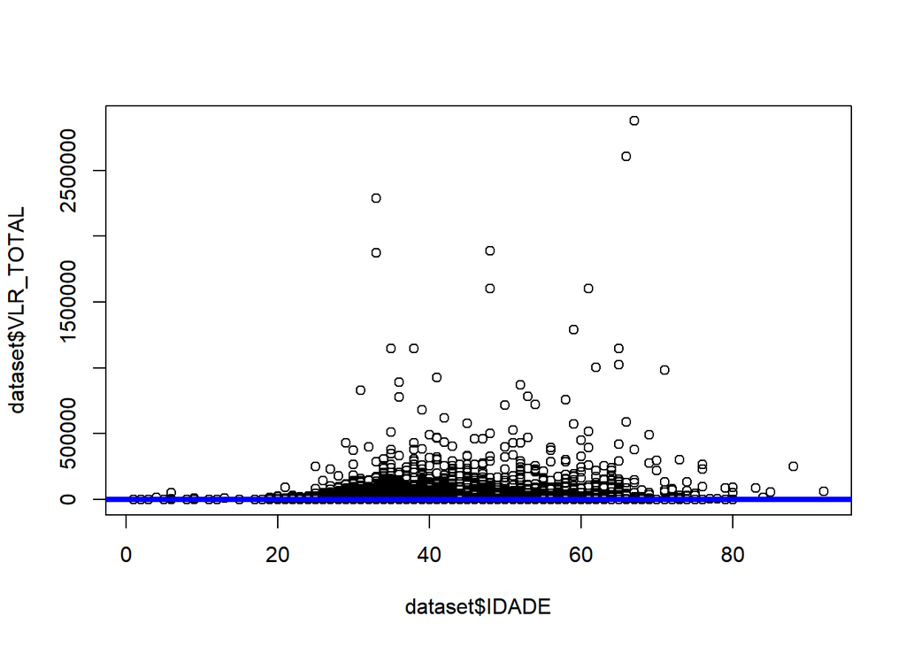

```r
plot(dataset$IDADE, dataset$VLR_TOTAL)
abline(linearModel, col='blue', lwd=4)
```

Dessa forma é possível ver que temos outliers a partir de 1000000 (realmente sabemos como é difícil ser um milionário).

# Vamos remover os outliers para melhor visualizar os dados

Como mais acima já fizemos a sumarização dos dados identificamos os seus quartis, vamos recortar os dados excluindo registros acima do 3º Quartil.

```r
dataset1 <- subset(dataset, VLR_TOTAL <= quartil3)
summary(dataset1)
```

```
##        ID       GEO_REFERENCIA  DATA_NASCIMENTO
##  Min.   :   1   Min.   : 10.0   Min.   :1933-02-17 00:00:00
##  1st Qu.:1275   1st Qu.: 79.0   1st Qu.:1980-02-25 00:00:00
##  Median :2504   Median :227.0   Median :1985-10-29 00:00:00
##  Mean   :2495   Mean   :344.5   Mean   :1983-11-29 04:28:03
##  3rd Qu.:3725   3rd Qu.:629.0   3rd Qu.:1990-03-07 00:00:00
##  Max.   :4972   Max.   :999.0   Max.   :2016-08-01 00:00:00
##
##                                  PROFISSAO    GENERO
##  ANALISTA DE SISTEMAS                 : 443   F: 898
##  ESTUDANTE                            : 378   M:2831
##  ENGENHEIRO                           : 311
##  ADMINISTRADOR                        : 308
##  AUTÔNOMO                             : 224
##  AUXILIAR DE ESCRITÓRIO E ASSEMELHADOS: 207
##  (Other)                              :1858
##                               ESTADO_CIVIL     VALOR_01
##  SOLTEIRO(A)                        :2090   Min.   :    0.0
##  CASADO(A) COM BRASILEIRO(A) NATO(A):1275   1st Qu.:  571.4
##  UNIAO ESTAVEL                      : 197   Median : 1000.0
##  DIVORCIADO(A)                      : 112   Mean   : 1435.2
##  VIUVO(A)                           :  22   3rd Qu.: 1857.1
##  CASADO(A) COM ESTRANGEIRO(A)       :  13   Max.   :14857.1
##  (Other)                            :  20
##     VALOR_02          VALOR_03        VALOR_04        PERFIL
##  Min.   :    0.0   Min.   :    0   Min.   :    0.00   A:2859
##  1st Qu.:    0.0   1st Qu.:    0   1st Qu.:    0.00   B: 602
##  Median :    0.0   Median :    0   Median :    0.00   C: 166
##  Mean   :  901.9   Mean   :  211   Mean   :  781.25   D: 102
##  3rd Qu.:    0.0   3rd Qu.:    0   3rd Qu.:   28.57
##  Max.   :17142.9   Max.   :14286   Max.   :17142.86
##
##      IDADE         VLR_TOTAL
##  Min.   : 1.00   Min.   :    0.0
##  1st Qu.:27.00   1st Qu.:  714.3
##  Median :32.00   Median : 1473.7
##  Mean   :33.45   Mean   : 3329.4
##  3rd Qu.:37.00   3rd Qu.: 3885.7
##  Max.   :84.00   Max.   :18082.6
##
```

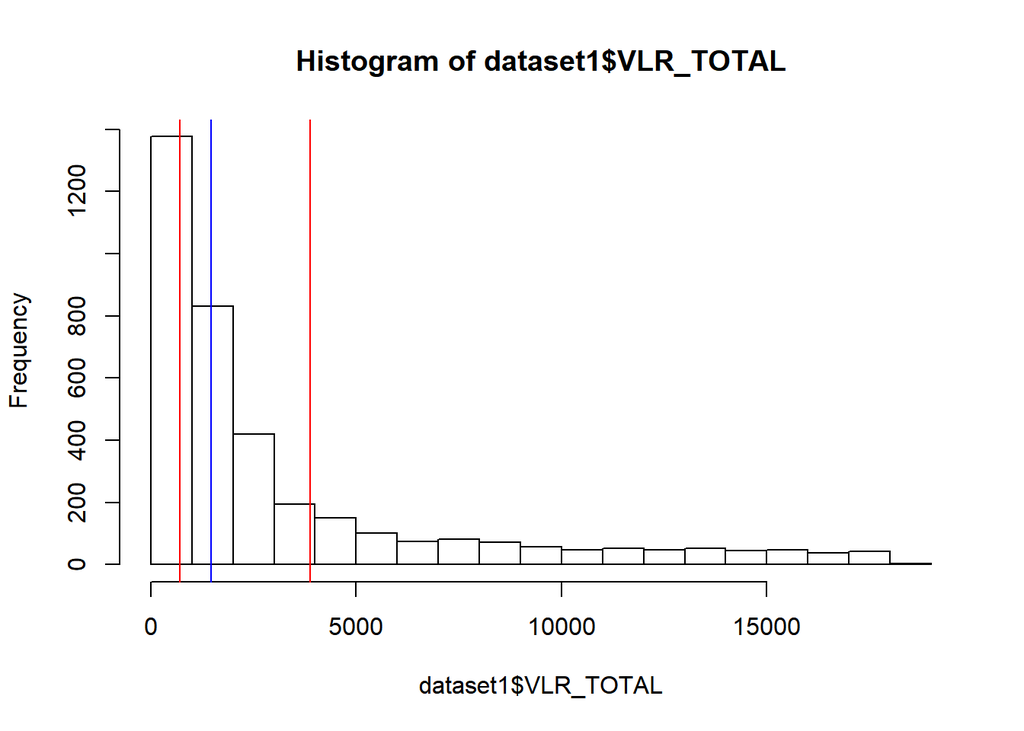

```r
q1 <- 714.3
mediana1 <- 1473.7
q3 <- 3885.7
hist(dataset1$VLR_TOTAL)
abline(v=q1, col="red")
abline(v=q3, col="red")
abline(v=mediana1, col="blue" )
```

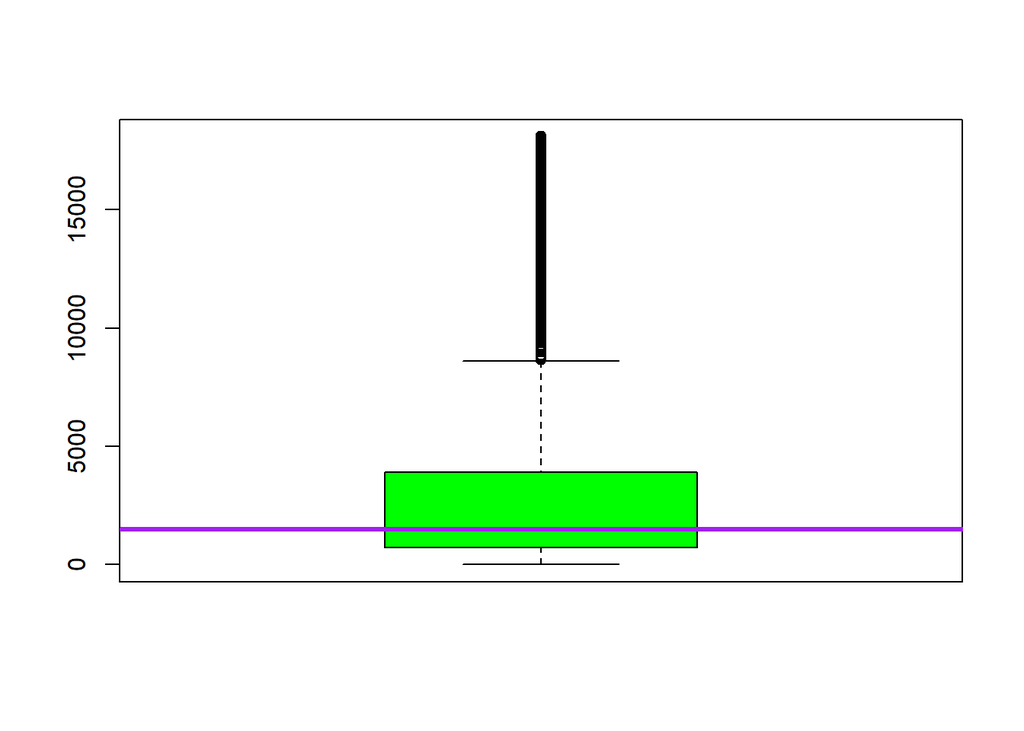

```r
boxplot(dataset1$VLR_TOTAL, col="green")
abline(h=mediana1, col="purple", lwd=3)
```

Ainda assim sobrou bastante outlier. Nos dá a impressão que os clientes dessa corretora em sua maioria possuem menos de 5000 investidos.

## Fazendo uma separação por gêneros para avaliação

Vamos separar o dataset entre os gêneros feminino e masculino para avaliar a evolução do valor total investido.

### Gênero Feminino

```r
datasetF <- subset(dataset, GENERO == "F")
summary(datasetF)
```

```
##        ID       GEO_REFERENCIA  DATA_NASCIMENTO
##  Min.   :   2   Min.   : 10.0   Min.   :1932-06-02 00:00:00
##  1st Qu.:1256   1st Qu.: 62.5   1st Qu.:1977-09-27 00:00:00
##  Median :2529   Median :215.0   Median :1984-08-24 00:00:00
##  Mean   :2513   Mean   :320.9   Mean   :1981-07-28 14:56:15
##  3rd Qu.:3746   3rd Qu.:582.5   3rd Qu.:1989-07-19 00:00:00
##  Max.   :4969   Max.   :982.0   Max.   :2015-04-08 00:00:00
##
##                                  PROFISSAO   GENERO
##  ESTUDANTE                            :113   F:1107
##  ADMINISTRADOR                        : 94   M:   0
##  AUXILIAR DE ESCRITÓRIO E ASSEMELHADOS: 84
##  AUTÔNOMO                             : 76
##  SERVIDOR PÚBLICO FEDERAL             : 62
##  ENGENHEIRO                           : 58
##  (Other)                              :620
##                               ESTADO_CIVIL    VALOR_01
##  SOLTEIRO(A)                        :602   Min.   :     0.0
##  CASADO(A) COM BRASILEIRO(A) NATO(A):351   1st Qu.:   571.4
##  UNIAO ESTAVEL                      : 56   Median :  1142.9
##  DIVORCIADO(A)                      : 52   Mean   :  1880.1
##  VIUVO(A)                           : 25   3rd Qu.:  2000.0
##  CASADO(A) COM ESTRANGEIRO(A)       : 12   Max.   :400000.0
##  (Other)                            :  9
##     VALOR_02          VALOR_03         VALOR_04        PERFIL
##  Min.   :      0   Min.   :     0   Min.   :     0.0   A:882
##  1st Qu.:      0   1st Qu.:     0   1st Qu.:     0.0   B:140
##  Median :      0   Median :     0   Median :     0.0   C: 54
##  Mean   :  11090   Mean   :  1295   Mean   :  4170.3   D: 31
##  3rd Qu.:   1714   3rd Qu.:     0   3rd Qu.:   649.6
##  Max.   :1285714   Max.   :214286   Max.   :571428.6
##
##      IDADE         VLR_TOTAL
##  Min.   : 2.00   Min.   :     28.6
##  1st Qu.:28.00   1st Qu.:    800.0
##  Median :33.00   Median :   1885.7
##  Mean   :35.77   Mean   :  18435.5
##  3rd Qu.:40.00   3rd Qu.:  11828.6
##  Max.   :85.00   Max.   :1291428.6
##
```

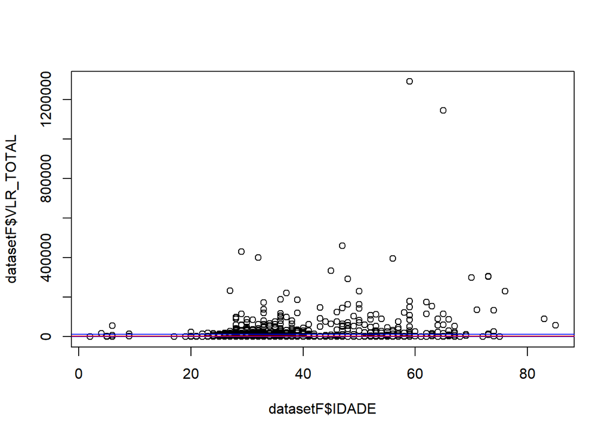

```r
q1F <- 800
medianaF <- 1885.7
q3F <- 11828.6

plot(datasetF$IDADE, datasetF$VLR_TOTAL)
abline(h=q1F, col="blue")
abline(h=medianaF, col="red")
abline(h=q3F, col="blue")
```

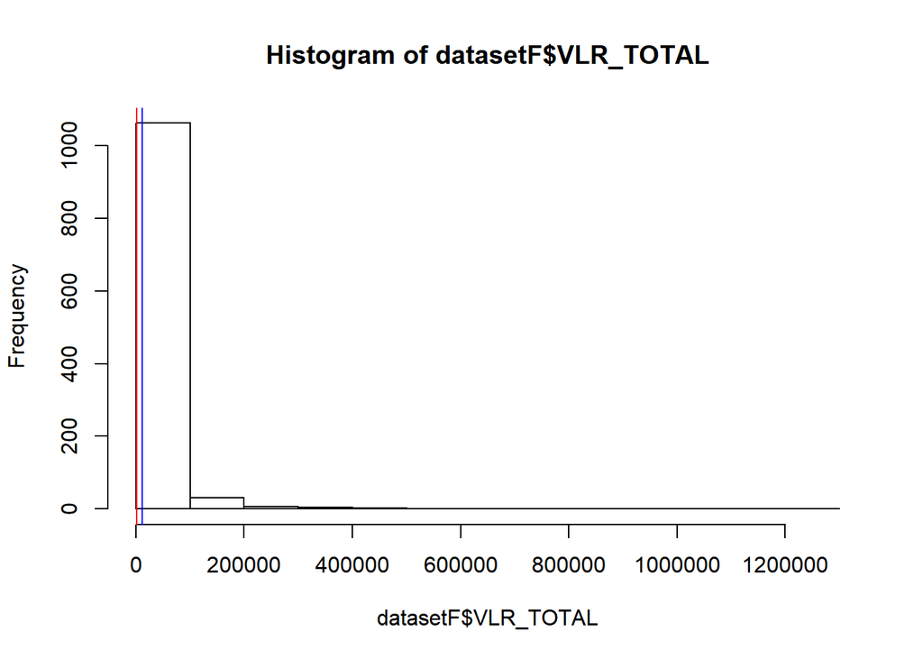

```r
hist(datasetF$VLR_TOTAL)
abline(v=q1F, col="blue")
abline(v=medianaF, col="red")
abline(v=q3F, col="blue")
```

### Gênero Masculino

```r
datasetM <- subset(dataset, GENERO == "M")
summary(datasetM)
```

```
##        ID       GEO_REFERENCIA  DATA_NASCIMENTO
##  Min.   :   1   Min.   : 10.0   Min.   :1925-11-03 00:00:00
##  1st Qu.:1241   1st Qu.: 76.0   1st Qu.:1977-07-05 00:00:00
##  Median :2477   Median :227.0   Median :1984-03-02 00:00:00
##  Mean   :2479   Mean   :341.4   Mean   :1982-01-14 00:47:45
##  3rd Qu.:3722   3rd Qu.:619.0   3rd Qu.:1988-12-22 00:00:00
##  Max.   :4972   Max.   :999.0   Max.   :2016-08-01 00:00:00
##
##                     PROFISSAO    GENERO
##  ANALISTA DE SISTEMAS    : 509   F:   0
##  ENGENHEIRO              : 447   M:3865
##  ADMINISTRADOR           : 348
##  ESTUDANTE               : 296
##  SERVIDOR PÚBLICO FEDERAL: 217
##  AUTÔNOMO                : 193
##  (Other)                 :1855
##                                       ESTADO_CIVIL     VALOR_01
##  SOLTEIRO(A)                                :1982   Min.   :    0.0
##  CASADO(A) COM BRASILEIRO(A) NATO(A)        :1519   1st Qu.:  685.7
##  UNIAO ESTAVEL                              : 211   Median : 1428.6
##  DIVORCIADO(A)                              : 112   Mean   : 2063.5
##  DESQUITADO(A)                              :  13   3rd Qu.: 2714.3
##  CASADO(A) COM BRASILEIRO(A) NATURALIZADO(A):  10   Max.   :71428.6
##  (Other)                                    :  18
##     VALOR_02          VALOR_03          VALOR_04      PERFIL
##  Min.   :      0   Min.   :      0   Min.   :     0   A:2607
##  1st Qu.:      0   1st Qu.:      0   1st Qu.:     0   B: 965
##  Median :      0   Median :      0   Median :     0   C: 191
##  Mean   :  20800   Mean   :   5092   Mean   :  5290   D: 102
##  3rd Qu.:   7400   3rd Qu.:      0   3rd Qu.:  1429
##  Max.   :2857143   Max.   :1428571   Max.   :685714
##
##      IDADE         VLR_TOTAL
##  Min.   : 1.00   Min.   :      0
##  1st Qu.:28.00   1st Qu.:   1000
##  Median :33.00   Median :   2857
##  Mean   :35.33   Mean   :  33246
##  3rd Qu.:40.00   3rd Qu.:  21143
##  Max.   :92.00   Max.   :2874286
##
```

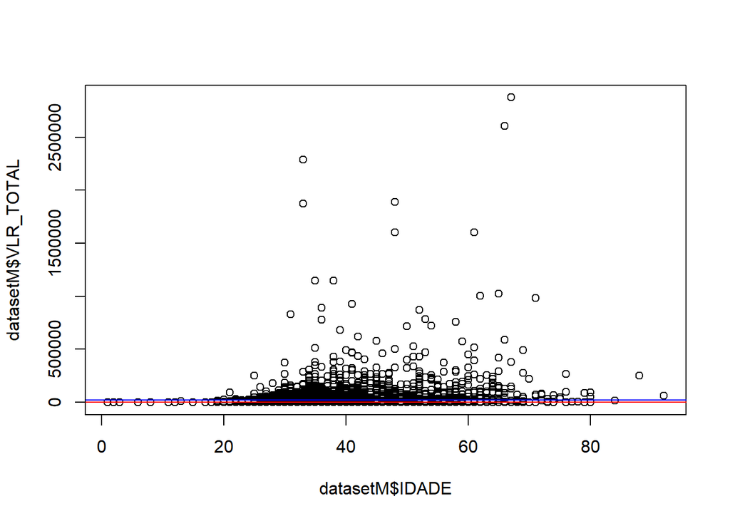

```r
q1M <- 1000
medianaM <- 2857
q3M <- 21143

plot(datasetM$IDADE, datasetM$VLR_TOTAL)
abline(h=q1M, col="blue")
abline(h=medianaM, col="red")
abline(h=q3M, col="blue")
```

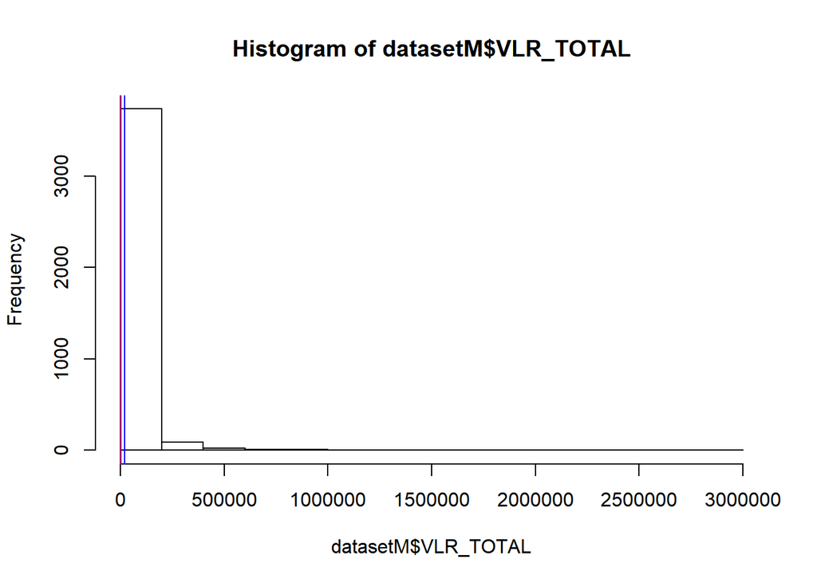

```r
hist(datasetM$VLR_TOTAL)
abline(v=q1M, col="blue")
abline(v=medianaM, col="red")
abline(v=q3M, col="blue")
```

## Tempo de execução

```r
end.time <- Sys.time()
time.taken <- end.time - start.time
time.taken
```

```
## Time difference of 24.52113 secs
```